# WHO COVID-19 Data Analysis

# 4 Descriptive Analysis

Let’s look at the daily number of new cases in the US, China and globally since Jan 3, 2020.

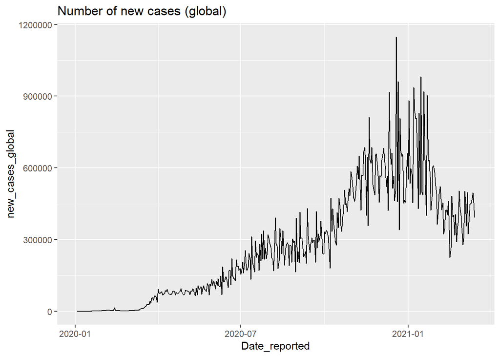

```r
covid <- read_csv("https://covid19.who.int/WHO-COVID-19-global-data.csv")
covid %>% group_by(Date_reported) %>%
  summarise(new_cases_global = sum(New_cases)) %>%
  ggplot(aes(y=new_cases_global, x=Date_reported)) +
  geom_line() +
  ggtitle("Number of new cases (global)")
```

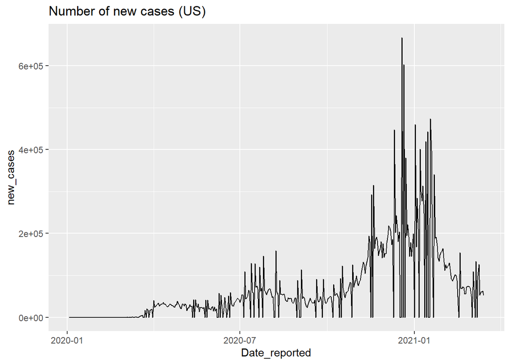

```r
covid %>% group_by(Date_reported) %>% filter(Country=="United States of America") %>%
  summarise(new_cases = sum(New_cases)) %>%
  ggplot(aes(y=new_cases, x=Date_reported)) +
  geom_line() +
  ggtitle("Number of new cases (US)")
```

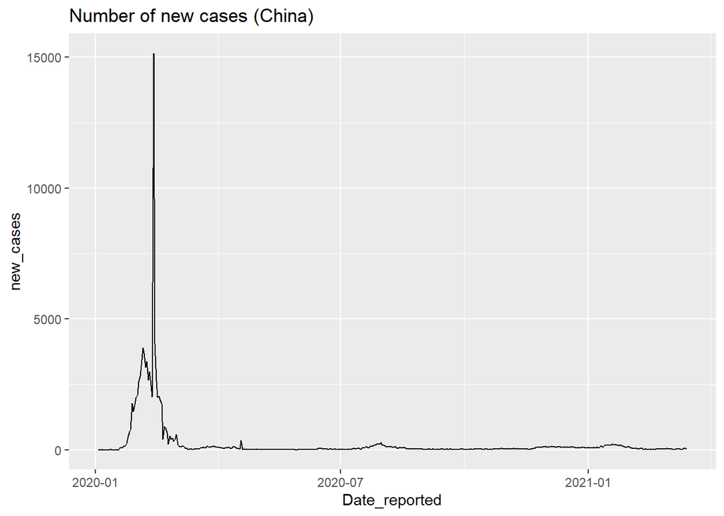

```r
covid %>% group_by(Date_reported) %>% filter(Country=="China") %>%
  summarise(new_cases = sum(New_cases)) %>%
  ggplot(aes(y=new_cases, x=Date_reported)) +
  geom_line() +
  ggtitle("Number of new cases (China)")
```

We can see that the number of new cases reaches a maximum around Jan 2021 and then decreases. Recently, we are interested in what reason cause the number of new cases decreases. After we looking for information online, it’s possibly because that there are several new type of covid-19 vaccines published, and people are getting vaccinated. In the United States, the number of new cases has a similar trend as the global data as most of countries globally. In China, the number of new cases exploded in February 2020, but after that it maintained at a low level, it controlled the covid-19 very well as a few other countries did. This suggests that the pandemic developed differently in different countries.

Next, let’s look at the daily number of deaths in the US, China and globally since Jan 3, 2020.

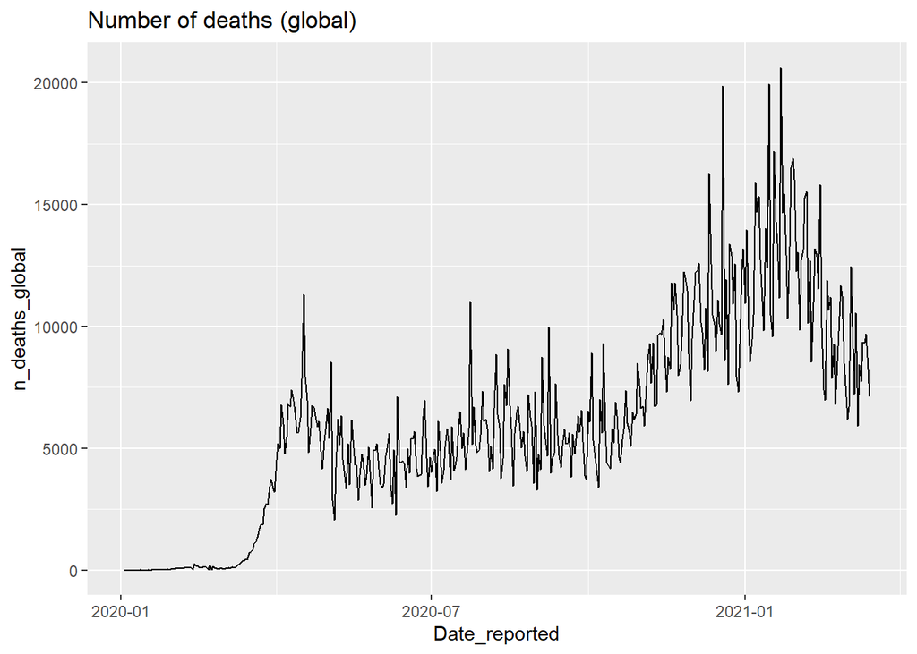

```r
covid %>% group_by(Date_reported) %>%
  summarise(n_deaths_global = sum(New_deaths)) %>%
  ggplot(aes(y=n_deaths_global, x=Date_reported)) +
  geom_line() +
  ggtitle("Number of deaths (global)")
```

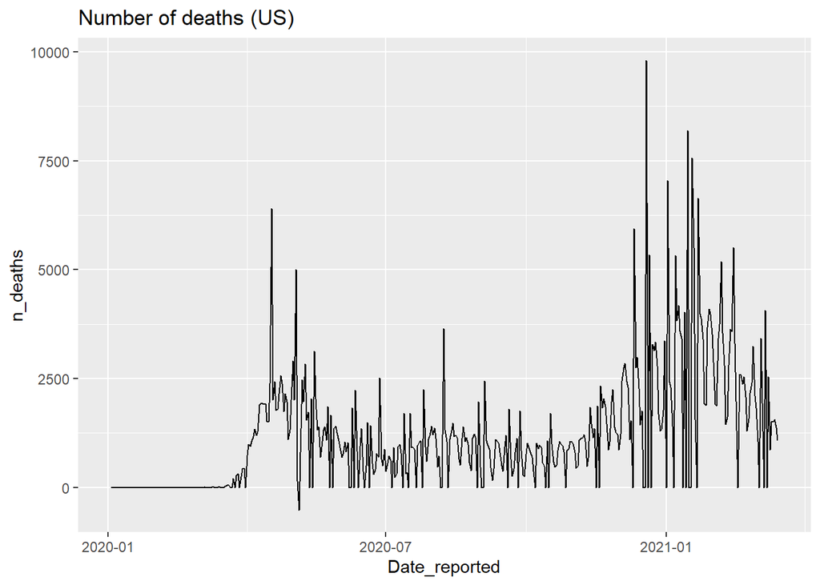

```r
covid %>% group_by(Date_reported) %>% filter(Country=="United States of America") %>%
  summarise(n_deaths = sum(New_deaths)) %>%
  ggplot(aes(y=n_deaths, x=Date_reported)) +
  geom_line() +
  ggtitle("Number of deaths (US)")
```

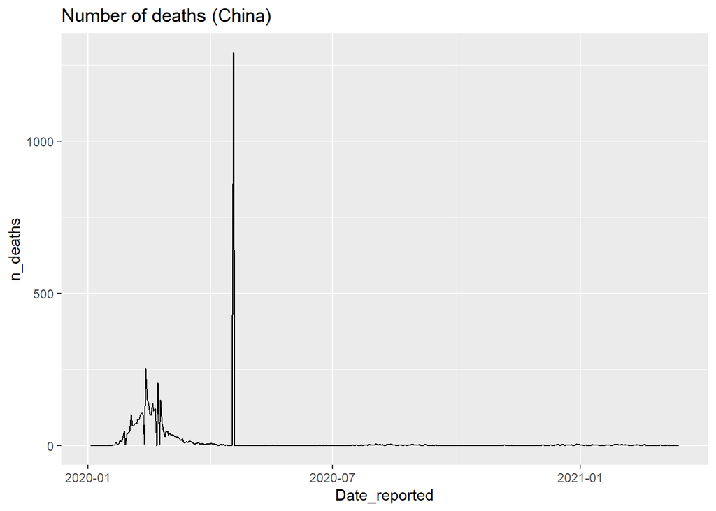

```r
covid %>% group_by(Date_reported) %>% filter(Country=="China") %>%
  summarise(n_deaths = sum(New_deaths)) %>%
  ggplot(aes(y=n_deaths, x=Date_reported)) +
  geom_line() +
  ggtitle("Number of deaths (China)")
```

```r
covid_motality_rate <- covid %>% filter(Date_reported=="2021-03-05") %>%
  mutate(rate = Cumulative_deaths / Cumulative_cases) %>%
  select(Country, rate, WHO_region, Cumulative_cases, Cumulative_deaths)
covid_motality_rate %>%
  arrange(desc(rate)) %>%
  head(10)
```

| Country | rate | WHO_region | Cumulative_cases | Cumulative_deaths |
| --- | --- | --- | --- | --- |
| Yemen | 0.27154266 | EMRO | 2379 | 646 |
| Mexico | 0.08933262 | AMRO | 2104987 | 188044 |
| Syrian Arab Republic | 0.06633657 | EMRO | 15753 | 1045 |
| Sudan | 0.06204977 | EMRO | 30540 | 1895 |
| Egypt | 0.05884009 | EMRO | 184755 | 10871 |
| Ecuador | 0.05508137 | AMRO | 289735 | 15959 |
| Montserrat | 0.05000000 | AMRO | 20 | 1 |
| Isle of Man | 0.04901961 | EURO | 510 | 25 |
| China | 0.04750282 | WPRO | 102015 | 4846 |
| Bolivia (Plurinational State of) | 0.04667629 | AMRO | 251391 | 11734 |

```r
covid_motality_rate %>%
  filter(rate>0) %>%
  arrange(rate) %>%
  head(10)
```

| Country | rate | WHO_region | Cumulative_cases | Cumulative_deaths |
| --- | --- | --- | --- | --- |
| Singapore | 0.0004833494 | WPRO | 59998 | 29 |
| Mongolia | 0.0006501951 | WPRO | 3076 | 2 |
| Bhutan | 0.0011534025 | SEARO | 867 | 1 |
| Burundi | 0.0013392857 | AFRO | 2240 | 3 |
| Faroe Islands | 0.0015197568 | EURO | 658 | 1 |
| Qatar | 0.0015705604 | EMRO | 165546 | 260 |
| Eritrea | 0.0024030209 | AFRO | 2913 | 7 |
| Maldives | 0.0031300435 | SEARO | 20447 | 64 |
| United Arab Emirates | 0.0031973745 | EMRO | 402205 | 1286 |
| Thailand | 0.0032392058 | SEARO | 26241 | 85 |

# 5 Inferential Analysis

We are going to answer the question: Does case-mortality rate differ among different regions? WHO divided countries into 7 regions: Regional Office for Africa (AFRO), Regional Office for the Americas (AMRO), Regional Office for the Eastern Mediterranean (EMRO), Regional Office for Europe (EURO), Regional Office for South East Asia (SEARO), Regional Office for the Western Pacific (WPRO) and other. We are going to use an ANOVA model to compare the case-mortality rate among these regions. The model is:

$$y = \beta_0 + \beta_1AFRO+\beta_2AMRO+\beta_3EMRO+\beta_4EURO+\beta_5SEARO+\beta_6WPRO+\epsilon$$

$y$ is the case-mortality rate, and there are six dummy variables for the six regions. Other region is chosen as the baseline group.

```r
covid_motality_rate$WHO_region <- relevel(factor(covid_motality_rate$WHO_region), ref="Other")
m <- aov(rate~WHO_region, covid_motality_rate)
summary(m)
```

```
##              Df  Sum Sq   Mean Sq F value  Pr(>F)
## WHO_region    6 0.00810 0.0013500   2.972 0.00827 **
## Residuals   216 0.09811 0.0004542
## ---
## Signif. codes:  0 '***' 0.001 '**' 0.01 '*' 0.05 '.' 0.1 ' ' 1
## 13 observations deleted due to missingness
```

```r
TukeyHSD(m)
```

```
##   Tukey multiple comparisons of means
##     95% family-wise confidence level
##
## Fit: aov(formula = rate ~ WHO_region, data = covid_motality_rate)
##
## $WHO_region
##                      diff           lwr           upr     p adj
## AFRO-Other   1.433376e-03 -6.264398e-02  0.0655107332 1.0000000
## AMRO-Other  -1.243136e-05 -6.400964e-02  0.0639847791 1.0000000
## EMRO-Other   1.761698e-02 -4.724202e-02  0.0824759691 0.9839309
## EURO-Other   7.723155e-04 -6.317886e-02  0.0647234948 1.0000000
## SEARO-Other -7.110844e-03 -7.364030e-02  0.0594186119 0.9999149
## WPRO-Other  -6.390506e-03 -7.113189e-02  0.0583508831 0.9999467
## AMRO-AFRO   -1.445807e-03 -1.385433e-02  0.0109627195 0.9998590
## EMRO-AFRO    1.618360e-02 -9.576431e-05  0.0324629629 0.0524890
## EURO-AFRO   -6.610604e-04 -1.282995e-02  0.0115078309 0.9999985
## SEARO-AFRO  -8.544220e-03 -3.055552e-02  0.0134670750 0.9097841
## WPRO-AFRO   -7.823882e-03 -2.362819e-02  0.0079804230 0.7602983
## EMRO-AMRO    1.762941e-02  1.668426e-03  0.0335903875 0.0199179
## EURO-AMRO    7.847469e-04 -1.095481e-02  0.0125243017 0.9999947
## SEARO-AMRO  -7.098413e-03 -2.887529e-02  0.0146784635 0.9598610
## WPRO-AMRO   -6.378075e-03 -2.185423e-02  0.0090980775 0.8831476
## EURO-EMRO   -1.684466e-02 -3.262006e-02 -0.0010692584 0.0278634
## SEARO-EMRO  -2.472782e-02 -4.892035e-02 -0.0005352899 0.0415195
## WPRO-EMRO   -2.400748e-02 -4.273066e-02 -0.0052843024 0.0033080
## SEARO-EURO  -7.883160e-03 -2.952439e-02  0.0137580676 0.9322146
## WPRO-EURO   -7.162821e-03 -2.244751e-02  0.0081218657 0.8041879
## WPRO-SEARO   7.203382e-04 -2.315511e-02  0.0245957828 1.0000000
```

# 6 Sensitivity analysis

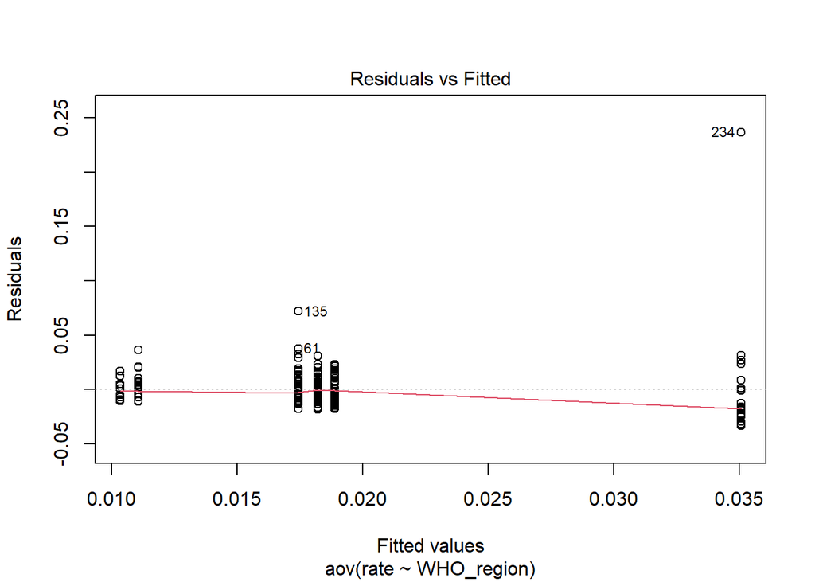

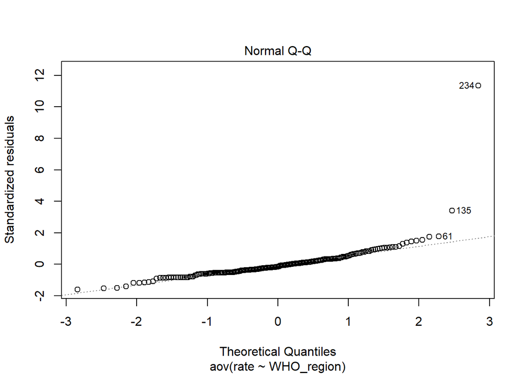

```r
plot(m, which =1:2)
```

```r
covid_motality_rate[235,]
```

| Country | rate | WHO_region | Cumulative_cases | Cumulative_deaths |
| --- | --- | --- | --- | --- |
| Zambia | 0.01374447 | AFRO | 80687 | 1109 |

```r
m <- aov(rate~WHO_region, covid_motality_rate[-c(135, 235),])
summary(m)
```

```
##              Df  Sum Sq   Mean Sq F value  Pr(>F)
## WHO_region    6 0.00836 0.0013929   3.211 0.00486 **
## Residuals   214 0.09282 0.0004337
## ---
## Signif. codes:  0 '***' 0.001 '**' 0.01 '*' 0.05 '.' 0.1 ' ' 1
## 13 observations deleted due to missingness
```

```r
TukeyHSD(m)
```

```
##   Tukey multiple comparisons of means
##     95% family-wise confidence level
##
## Fit: aov(formula = rate ~ WHO_region, data = covid_motality_rate[-c(135, 235), ])
##
## $WHO_region
##                      diff           lwr          upr     p adj
## AFRO-Other   0.0015404295 -0.0610947244  0.064175583 1.0000000
## AMRO-Other  -0.0013196202 -0.0638733769  0.061234137 1.0000000
## EMRO-Other   0.0176169753 -0.0457690188  0.081002969 0.9818974
## EURO-Other   0.0007723155 -0.0617264810  0.063271112 1.0000000
## SEARO-Other -0.0071108441 -0.0721293628  0.057907675 0.9999026
## WPRO-Other  -0.0063905059 -0.0696615661  0.056880554 0.9999390
## AMRO-AFRO   -0.0028600497 -0.0151050099  0.009384910 0.9927591
## EMRO-AFRO    0.0160765457  0.0001156306  0.032037461 0.0470742
## EURO-AFRO   -0.0007681140 -0.0127291402  0.011192912 0.9999958
## SEARO-AFRO  -0.0086512737 -0.0302006202  0.012898073 0.8954732
## WPRO-AFRO   -0.0079309355 -0.0234291167  0.007567246 0.7306029
## EMRO-AMRO    0.0189365955  0.0032981563  0.034575035 0.0070333
## EURO-AMRO    0.0020919357 -0.0094352545  0.013619126 0.9981985
## SEARO-AMRO  -0.0057912239 -0.0271028242  0.015520376 0.9838839
## WPRO-AMRO   -0.0050708857 -0.0202367550  0.010094984 0.9546042
## EURO-EMRO   -0.0168446597 -0.0322617891 -0.001427530 0.0222486
## SEARO-EMRO  -0.0247278194 -0.0483709171 -0.001084722 0.0338282
## WPRO-EMRO   -0.0240074812 -0.0423054416 -0.005709521 0.0023872
## SEARO-EURO  -0.0078831597 -0.0290328973  0.013266578 0.9247061
## WPRO-EURO   -0.0071628215 -0.0221003811  0.007774738 0.7865018
## WPRO-SEARO   0.0007203382 -0.0226128759  0.024053552 0.9999999
```